# Práctica 11

# 4 Lea la ayuda ?facet_wrap. ¿Qué hace nrow? ¿Qué hace ncol? ¿Qué hace otras opciones controlan el diseño de los paneles individuales? ¿Por qué facet_grid() no tiene argumentos nrow y ncol?

```r
?facet_wrap
```

```
## starting httpd help server ... done
```

```
Los argumentos nrow y ncol determinan el número de filas y columnas en el momento en que se generan las facetas, facet_wrap solo opera con una única variable.
nrow y ncol no son necesarios en facet_grid ya que el número de valores únicos en la función determina el número de filas y columnas.
```

# 5 Al usar facet_grid(), generalmente debe colocar la variable con más niveles únicos en las columnas. ¿Por qué?

```
Al hacer esto, se generan más espacios para las columnas si es que el gráfico que se desea graficar es de forma horizontal.
```

# 6 COMPLEMENTO DE PRÁCTICA

## 6.1 Use base de datos ToothGrowth, convierte la variable dose de númerica a factor

```r
data(ToothGrowth)
ToothGrowth$dose <- as.factor(ToothGrowth$dose)
```

## 6.2 Crea un gráfico tipo geom_boxplot(), donde x = dose, y = len, group = dose. Debe colocarse mediante fill = dose

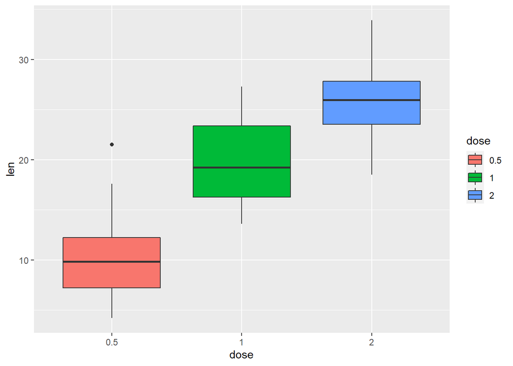

```r
bp <- ggplot(data = ToothGrowth, aes(x = dose, y = len, group = dose)) + geom_boxplot(aes(fill = dose))
bp
```

## 6.3 Faceta con una variable, el gráfico se dividirá en múltiples paneles por niveles de acuerdo a la variable “supp”:

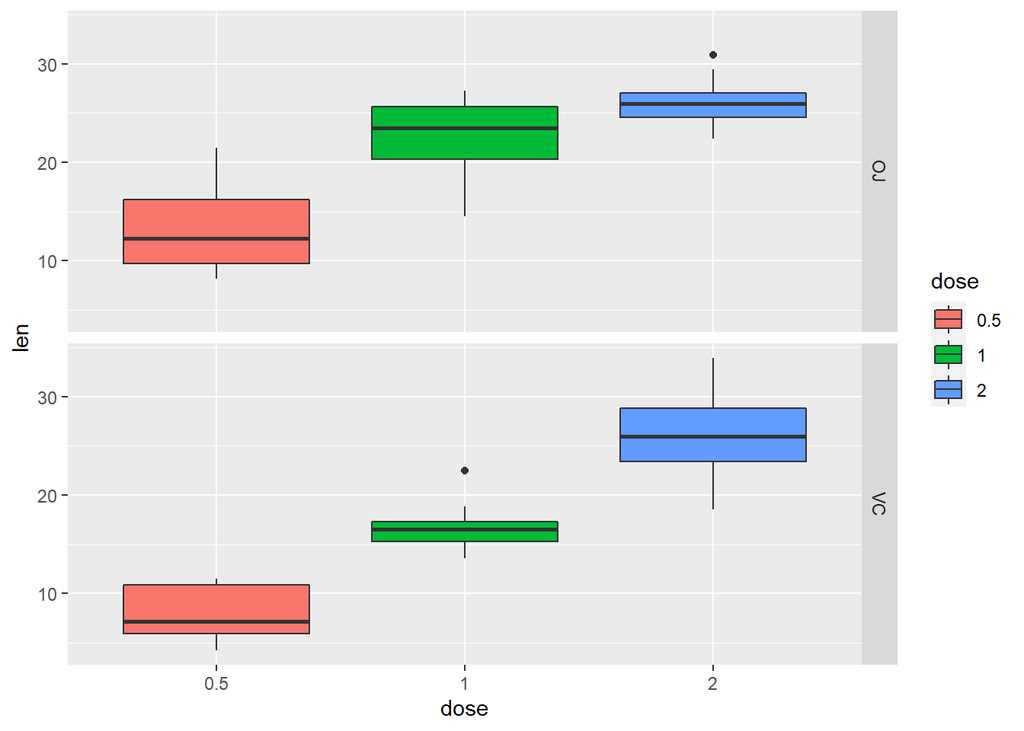

```r
# Separar en dirección vertical
bp + facet_grid(supp ~ .)
```

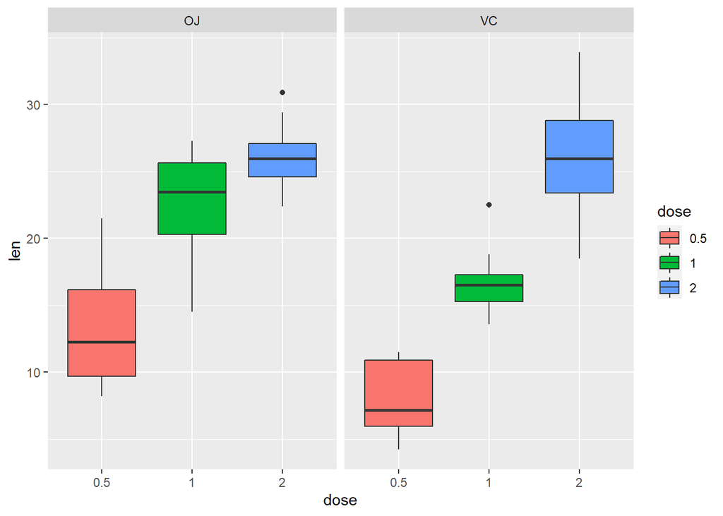

```r
# Separar en dirección horizontal
bp + facet_grid(. ~ supp)
```

## 6.4 Faceta con dos variables, el gráfico será dividido por los niveles de los grupos “dose” “supp”

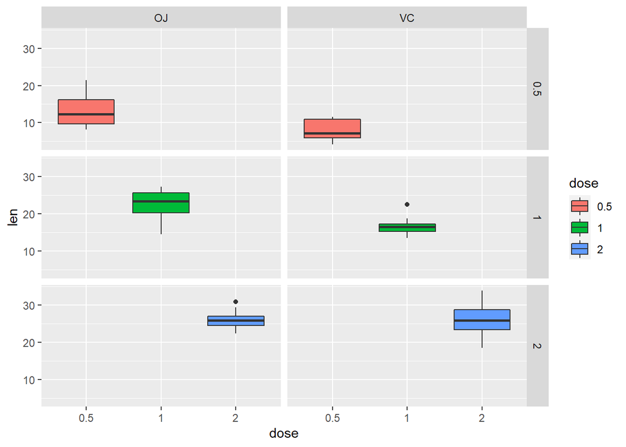

```r
# Faceta de dos variables: dose y supp.
# Fila es dose y columna es supp
bp + facet_grid(dose ~ supp)
```

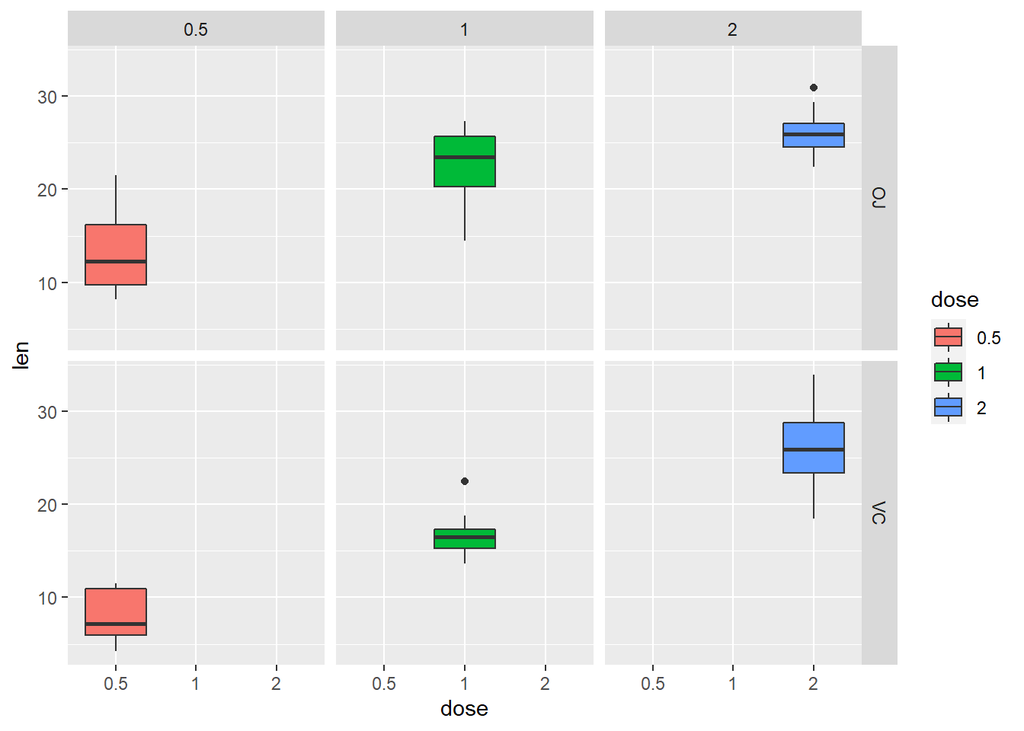

```r
# Faceta de dos variables: invertir el orden de las dos variables
# Fila es supp y columna es dose
bp + facet_grid(supp ~ dose)
```

## 6.5 ¿Qué pasa si agrega margins?

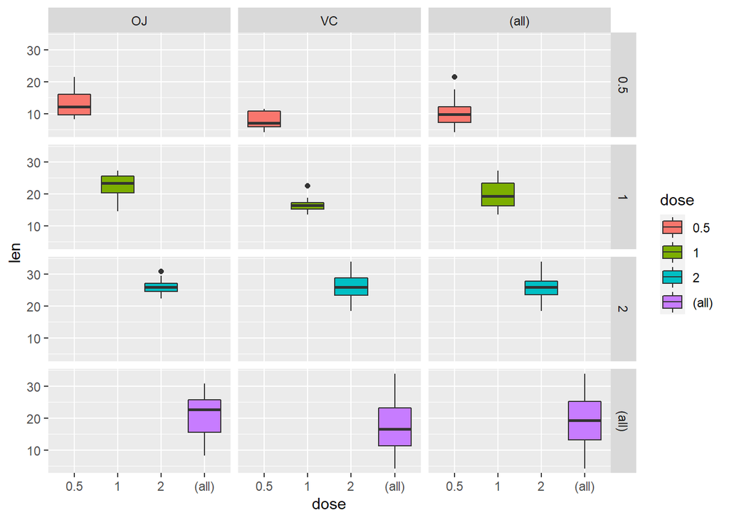

```
Los margenes sirven para agregar facetas adicionales que contiene todos los datos para cada uno de los valores posibles de las variables de las facetas.
```

```r
bp + facet_grid(dose ~ supp, margins = TRUE)
```